# Challenge 1: Descriptive Text Analysis

Pablo Barbera

July 2, 2018

This will be the first coding challenge of the course. The purpose of these exercises is for you to practice what we just went over in the guided coding session. You will have to write R code in the chunks within this RMarkdown file in order to answer each of the questions.

We will start with a dataset that contains slightly over 25,000 tweets published by the 4 leading candidates in the 2016 Presidential Primary Elections in the US (Cruz, Trump, Clinton, Sanders). Read the dataset into R and then use the `str` or `head` functions to get a sense of the variables that this dataset contains.

```r
data <- read.csv("../data/candidate-tweets.csv", stringsAsFactors=FALSE)
str(data)
```

```
## 'data.frame':    26735 obs. of  5 variables:
##  $ screen_name: chr  "realDonaldTrump" "realDonaldTrump" "realDonaldTrump" "realDonaldTrump" ...
##  $ text       : chr  "RT @GeraldoRivera: Recruit @realDonaldTrump to finish that horrid eyesore Meadowlands Xanadu &amp; cleanup NYs "| __truncated__ ".@GeraldoRivera Thanks, my champion Geraldo--and very true." "Trump signs lease for a NH office, returns Monday http://t.co/NLJQb8BmZB via  @Union…
##  $ datetime   : chr  "2015-04-23 16:04:33" "2015-04-23 16:04:42" "2015-04-23 16:53:47" "2015-04-23 17:08:34" ...
##  $ source     : chr  "<a href=\"http://twitter.com\" rel=\"nofollow\">Twitter Web Client</a>" "<a href=\"http://twitter.com\" rel=\"nofollow\">Twitter Web Client</a>" "<a href=\"http://twitter.com\" rel=\"nofollow\">Twitter Web Client</a>" "<a href=\"http://twitter.com\" rel=\"nofollow\">Twitter …
##  $ lang       : chr  "en" "en" "en" "en" ...
```

```r
head(data)
```

```
##       screen_name
## 1 realDonaldTrump
## 2 realDonaldTrump
## 3 realDonaldTrump
## 4 realDonaldTrump
## 5 realDonaldTrump
## 6 realDonaldTrump
##                                                                                                                                              text
## 1 RT @GeraldoRivera: Recruit @realDonaldTrump to finish that horrid eyesore Meadowlands Xanadu &amp; cleanup NYs equally horrid Gowanus Canal. Tr
## 2                                                                                     .@GeraldoRivera Thanks, my champion Geraldo--and very true.
## 3                                            Trump signs lease for a NH office, returns Monday http://t.co/NLJQb8BmZB via  @UnionLeader by @tuohy
## 4                            Excited to be travelling to New Hampshire on Monday. The Granite State is a model for the country. Live Free or Die!
## 5                                                Via @thehill by @HenschOnTheHill: Trump says US roads are 'falling apart' http://t.co/MhuHz1Su1J
## 6     RT @TrumpToronto: It's not luxury until you experience @Trumptoronto's service. Book your stay at http://t.co/hJ9agW5doT and experience #lu
##              datetime
## 1 2015-04-23 16:04:33
## 2 2015-04-23 16:04:42
## 3 2015-04-23 16:53:47
## 4 2015-04-23 17:08:34
## 5 2015-04-23 17:50:13
## 6 2015-04-23 18:00:28
##                                                               source lang
## 1 <a href="http://twitter.com" rel="nofollow">Twitter Web Client</a>   en
## 2 <a href="http://twitter.com" rel="nofollow">Twitter Web Client</a>   en
## 3 <a href="http://twitter.com" rel="nofollow">Twitter Web Client</a>   en
## 4 <a href="http://twitter.com" rel="nofollow">Twitter Web Client</a>   en
## 5 <a href="http://twitter.com" rel="nofollow">Twitter Web Client</a>   en
## 6 <a href="http://twitter.com" rel="nofollow">Twitter Web Client</a>   en
```

How many tweets are retweets? Create a new data frame that contains only original tweets (excluding retweets).

```r
length(grep('^RT @', data$text, ignore.case=TRUE))
```

```
## [1] 7271
```

```r
tweets <- data[grepl('^RT @', data$text, ignore.case=TRUE)==FALSE,]
```

How many tweets were sent by each of the candidates? Create another (smaller) data frame that contains only tweets by Bernie Sanders.

```r
table(tweets$screen_name)
```

```
##
##   BernieSanders  HillaryClinton realDonaldTrump         tedcruz
##            3008            4329            6964            5163
```

```r
sanders <- tweets[tweets$screen_name=="BernieSanders",]
```

How many times did Bernie Sanders mention words related to ‘health care’? and ‘immigration’? and ‘billionaires’? ‘gun control’? ‘poverty’? Use regular expressions to make sure your searches return all relevant results.

```r
length(grep('health', sanders$text, ignore.case=TRUE))
```

```
## [1] 148
```

```r
length(grep('immigr*', sanders$text, ignore.case=TRUE))
```

```
## [1] 37
```

```r
length(grep('guns', sanders$text, ignore.case=TRUE))
```

```
## [1] 3
```

```r
length(grep('minimum wage', sanders$text, ignore.case=TRUE))
```

```
## [1] 45
```

```r
length(grep('poverty', sanders$text, ignore.case=TRUE))
```

```
## [1] 65
```

What are the 10 most frequent hashtags in the tweets by Bernie Sanders? Try to answer this question creating a function, instead of copying and pasting the code from earlier in the class.

```r
library(stringr)
top_hashtags <- function(text){
  hashtags <- str_extract_all(text, '#[A-Za-z0-9_]+')
  return(
    head(sort(table(unlist(hashtags)), decreasing = TRUE), n=10)
    )
}

top_hashtags(sanders$text)
```

```
##
##        #DemDebate #DebateWithBernie      #DemTownHall        #BreakEmUp
##               105                47                34                25
##  #CaucusForBernie  #AmericaTogether       #Bernie2016      #SuperMonday
##                25                19                19                18
##     #VoteTogether          #NotMeUs
##                18                16
```

Now, find the 10 most frequent hashtags for each candidate. You can use a loop to answer this question or just run the above function for each candidate separately.

```r
cands <- unique(tweets$screen_name)

for (cand in cands){
  message(cand)
  print(top_hashtags(tweets$text[tweets$screen_name==cand]))
}
```

```
## realDonaldTrump
```

```
##
##             #Trump2016 #MakeAmericaGreatAgain             #VoteTrump
##                    611                    470                     68
##             #GOPDebate                  #FITN                 #Trump
##                     41                     37                     36
##             #DemDebate            #TrumpTrain                     #1
##                     33                     26                     24
##              #IACaucus
##                     24
```

```
## HillaryClinton
```

```
##
##    #DemDebate    #GOPdebate  #Hillary2016  #DemTownHall    #ImWithHer
##           221           138           104            55            37
##        #IDPJJ #SuperTuesday          #TBT     #DemForum         #SOTU
##            15            13            13            11            11
```

```
## tedcruz
```

```
##
##         #CruzCrew        #GOPDebate       #ChooseCruz      #CruzCountry
##               602               277               195               148
##     #MakeDCListen       #FullRepeal    #CaucusForCruz    #CruzToVictory
##               143               140                96                88
##   #CruzinToCaucus #WashingtonCartel
##                84                84
```

```
## BernieSanders
```

```
##
##        #DemDebate #DebateWithBernie      #DemTownHall        #BreakEmUp
##               105                47                34                25
##  #CaucusForBernie  #AmericaTogether       #Bernie2016      #SuperMonday
##                25                19                19                18
##     #VoteTogether          #NotMeUs
##                18                16
```

Now going to back to the dataset with tweets by Bernie Sanders, try to create a corpus and DFM object. Think carefully through the different options (e.g. should you exclude stopwords?). Then, look at the 25 most frequent words.

```r
library(quanteda)
sanders_dfm <- dfm(corpus(sanders$text), remove=stopwords("english"),
                   remove_punct=TRUE, remove_url=TRUE)
topfeatures(sanders_dfm, n=25)
```

```
##    people   country      must      need  campaign      vote     today
##       393       246       245       236       226       224       222
##       can    bernie        us political    change     right      wall
##       219       182       179       165       157       157       156
##      make    street    health       one   america      care      just
##       155       146       145       145       140       138       133
##       get      time americans  american
##       131       129       124       123
```

Plot the DFM you just created using a wordcloud. What do you learn?

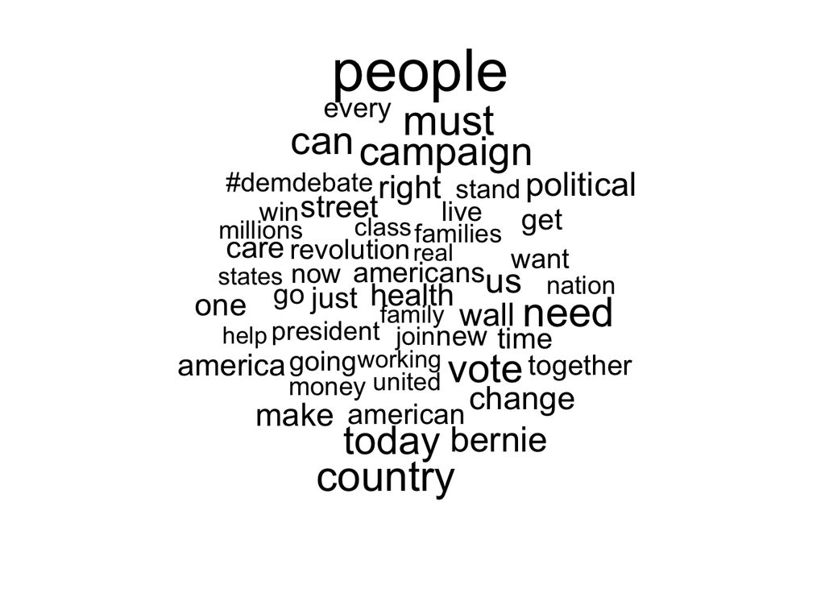

```r
textplot_wordcloud(sanders_dfm, rot.per=0, scale=c(3, .75), max.words=50)
```

The variable `source` contains information about the device from which each tweet was sent. How many tweets did each candidate send from an Android device? and from an iphone? Use regular expressions applied to the `source` variable to answer this question.

```r
table(
  grepl('android', tweets$source, ignore.case = TRUE),
  tweets$screen_name
)
```

```
##
##         BernieSanders HillaryClinton realDonaldTrump tedcruz
##   FALSE          2979           4329            2664    5163
##   TRUE             29              0            4300       0
```

```r
table(
  grepl('iphone', tweets$source, ignore.case = TRUE),
  tweets$screen_name
)
```

```
##
##         BernieSanders HillaryClinton realDonaldTrump tedcruz
##   FALSE          2842           4089            5750    3865
##   TRUE            166            240            1214    1298
```